# COVID-19 Vaccine Data Analysis

KCS

2/7/2022

## COVID-19 Vaccine Data Analysis

In this report, we will be conduct an analysis of the publicly available COVID-19 vaccination data.

The primary goal of this analysis is to gain deeper insight into the relationship between vaccine administration and the number of new deaths from COVID-19. By analyzing trends over time, we aim to better understand the potential impact of vaccination efforts on reducing mortality rates during the pandemic.

First, please make sure to install and library() the packages below. These are essential to being able to reproduce this analysis in rmarkdown.

```r
library(prettydoc)
library(tidyverse)
library(lubridate)
library(dplyr)
```

First we will perform exploratory analysis on the data and then do some statistical modelling for vaccine and new death cases

Locate, copy the file names and and read the urls from the COVID public data from github

```r
url_in<-"https://raw.githubusercontent.com/CSSEGISandData/COVID-19/master/csse_covid_19_data/csse_covid_19_time_series/"
file_names<- c(
  "time_series_covid19_confirmed_global.csv",
  "time_series_covid19_deaths_global.csv",
  "time_series_covid19_confirmed_US.csv",
  "time_series_covid19_deaths_US.csv")
urls<-str_c(url_in,file_names)

##read datasets
global_cases<-read_csv(urls[1])
global_deaths<-read_csv(urls[2])
US_cases<-read_csv(urls[3])
US_deaths<-read_csv(urls[4])
```

## Tidying and data wrangling

To keep things simple, we will focus on US cases only for this analysis. Join cases and deaths data together and get US data by state and US totals

```r
##read datasets
#cases
US_cases<-US_cases %>%
  pivot_longer(cols=-(UID:Combined_Key),
               names_to="date",
               values_to="cases") %>%
  select(Admin2:cases) %>%
  mutate(date=mdy(date)) %>%
  select(-c(Lat,Long_))
##deaths
US_deaths<-US_deaths %>%
  pivot_longer(cols=-(UID:Population),
               names_to= "date",
               values_to="deaths") %>%
  select(Admin2:deaths) %>%
  mutate(date=mdy(date)) %>%
  select(-c(Lat,Long_))

##fulljoin cases and deaths
US<-US_cases %>%
  full_join(US_deaths)

US_by_state<- US %>%
  group_by(Province_State, Country_Region, date) %>%
  summarize(cases=sum(cases),deaths=sum(deaths),
            Population=sum(Population))%>%
  mutate(deaths_per_mill=deaths*1000000/Population)%>%
  select(Province_State,Country_Region,date,
         cases, deaths, deaths_per_mill, Population) %>%
  ungroup()

US_totals<- US_by_state %>%
  group_by(Country_Region,date) %>%
  summarize(cases=sum(cases),deaths=sum(deaths),
            Population=sum(Population))%>%
  mutate(deaths_per_mill=deaths*1000000/Population)%>%
  select(Country_Region,date,
         cases, deaths, deaths_per_mill, Population) %>%
  ungroup()
```

## Exploratory Analysis and Visualization

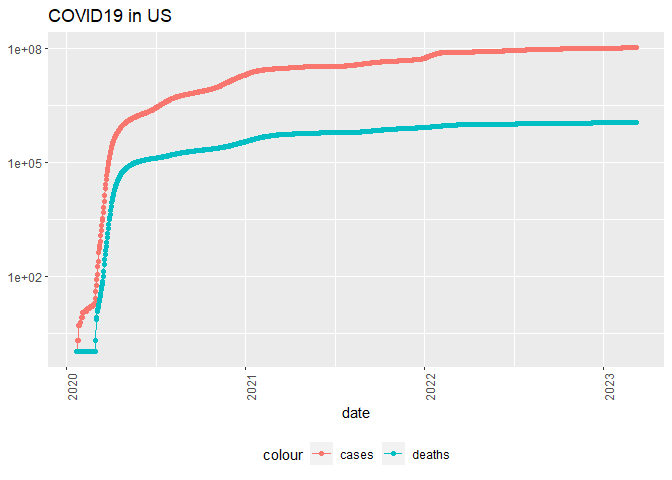

```r
##Let's visualize our data and analyze it
US_totals %>%
  filter(cases>0) %>%
  ggplot(aes(x=date, y=cases))+
  geom_line(aes(color="cases"))+
  geom_point(aes(color="cases"))+
  geom_line(aes(y=deaths, color="deaths"))+
  geom_point(aes(y=deaths, color="deaths"))+
  scale_y_log10()+
  theme(legend.position="bottom",
        axis.text.x=element_text(angle = 90))+
  labs(title = "COVID19 in US",y=NULL)
```

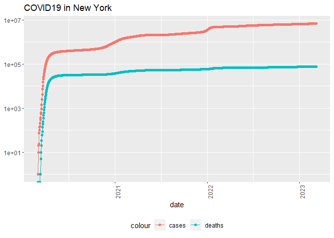

```r
##Let's filter by the state of New York and visualize cases and deaths
state<- "New York"
US_by_state %>%
  filter(Province_State== state) %>%
  filter(cases>0) %>%
  ggplot(aes(x=date, y=cases))+
  geom_line(aes(color="cases"))+
  geom_point(aes(color="cases"))+
  geom_line(aes(y=deaths, color="deaths"))+
  geom_point(aes(y=deaths, color="deaths"))+
  scale_y_log10()+
  theme(legend.position="bottom",
        axis.text.x=element_text(angle = 90))+
  labs(title = str_c("COVID19 in ", state),y=NULL)
```

```r
##check what is the max death
max(US_totals$deaths)
```

```
## [1] 1123836
```

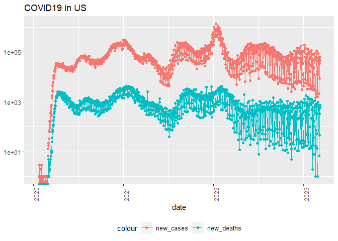

```r
##let's add in new_cases and new deaths as additional variables.
##This will be important when looking into vaccintion date after

US_by_state<-US_by_state %>%
  mutate(new_cases= cases-lag(cases),
         new_deaths=deaths-lag(deaths))
US_totals<-US_totals %>%
  mutate(new_cases= cases-lag(cases),
         new_deaths=deaths-lag(deaths))

##tail(US_totals %>% select(new_cases, new_deaths, everything()))

##Now graph new cases and new deaths
US_totals %>%
  ggplot(aes(x=date, y=new_cases))+
  geom_line(aes(color="new_cases"))+
  geom_point(aes(color="new_cases"))+
  geom_line(aes(y=new_deaths, color="new_deaths"))+
  geom_point(aes(y=new_deaths, color="new_deaths"))+
  scale_y_log10()+
  theme(legend.position="bottom",
        axis.text.x=element_text(angle = 90))+
  labs(title = "COVID19 in US",y=NULL)
```

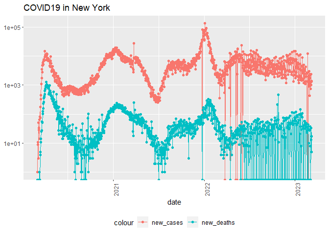

```r
##Let's single out NEw York and see how that looks
US_by_state %>%
  filter(Province_State== state) %>%
  filter(cases>0) %>%
  ggplot(aes(x=date, y=new_cases))+
  geom_line(aes(color="new_cases"))+
  geom_point(aes(color="new_cases"))+
  geom_line(aes(y=new_deaths, color="new_deaths"))+
  geom_point(aes(y=new_deaths, color="new_deaths"))+
  scale_y_log10()+
  theme(legend.position="bottom",
        axis.text.x=element_text(angle = 90))+
  labs(title = str_c("COVID19 in ", state),y=NULL)
```

```r
##which are the worst and bast states?
US_state_totals<- US_by_state %>%
  group_by(Province_State) %>%
  summarize(deaths=max(deaths), cases=max(cases),
            population=max(Population),
            cases_per_thou=1000*cases/population,
            deaths_per_thou=1000*deaths/population) %>%
  filter(cases>0,population>0)
```

Below is the code for checking lowest and highest death. Now we need to run the code for this analysis

```r
##states with lowest deaths
US_state_totals%>%
  slice_min(deaths_per_thou,n=10) %>%
  select(deaths_per_thou, cases_per_thou, everything())

##stats with highest death
US_state_totals%>%
  slice_max(deaths_per_thou,n=10) %>%
  select(deaths_per_thou, cases_per_thou, everything())
```

[output not shown]

## Modelling and Statistical Analysis

We will use a linear model to predict deaths from cases

```r
mod<-lm(deaths_per_thou~cases_per_thou, data=US_state_totals)
summary(mod)
```

```
##
## Call:
## lm(formula = deaths_per_thou ~ cases_per_thou, data = US_state_totals)
##
## Residuals:
##     Min      1Q  Median      3Q     Max
## -2.3352 -0.5978  0.1491  0.6535  1.2086
##
## Coefficients:
##                Estimate Std. Error t value Pr(>|t|)
## (Intercept)    -0.36167    0.72480  -0.499     0.62
## cases_per_thou  0.01133    0.00232   4.881 9.76e-06 ***
## ---
## Signif. codes:  0 '***' 0.001 '**' 0.01 '*' 0.05 '.' 0.1 ' ' 1
##
## Residual standard error: 0.8615 on 54 degrees of freedom
## Multiple R-squared:  0.3061, Adjusted R-squared:  0.2933
## F-statistic: 23.82 on 1 and 54 DF,  p-value: 9.763e-06
```

Plot the predicted deaths against actual death

```r
##check info
##US_state_totals %>% slice_min(cases_per_thou)
##US_state_totals %>% slice_max(cases_per_thou)

x_grid<-seq(1,151)
new_df<-tibble(cases_per_thou=x_grid)
US_state_totals%>% mutate(pred=predict(mod))
```

```
## # A tibble: 56 × 7
##    Province_State  deaths  cases population cases_per_thou deaths_per_thou  pred
##    <chr>            <dbl>  <dbl>      <dbl>          <dbl>           <dbl> <dbl>
##  1 Alabama          21032 1.64e6    4903185           335.           4.29   3.44
##  2 Alaska            1486 3.08e5     740995           415.           2.01   4.34
##  3 American Samoa      34 8.32e3      55641           150.           0.611  1.33
##  4 Arizona          33102 2.44e6    7278717           336.           4.55   3.44
##  5 Arkansas         13020 1.01e6    3017804           334.           4.31   3.42
##  6 California      101159 1.21e7   39512223           307.           2.56   3.12
##  7 Colorado         14181 1.76e6    5758736           306.           2.46   3.11
##  8 Connecticut      12220 9.77e5    3565287           274.           3.43   2.74
##  9 Delaware          3324 3.31e5     973764           340.           3.41   3.49
## 10 District of Co…   1432 1.78e5     705749           252.           2.03   2.49
## # ℹ 46 more rows
```

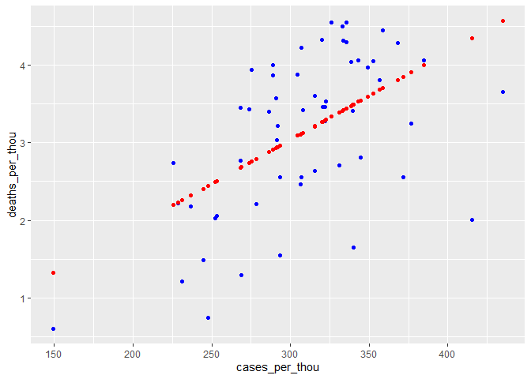

```r
US_tot_w_pred<-US_state_totals%>% mutate(pred=predict(mod))

##finally plot cases per thousand vs deaths per thousand
US_tot_w_pred %>% ggplot()+
  geom_point(aes(x=cases_per_thou,
                 y=deaths_per_thou),
             color="blue")+
  geom_point(aes(x=cases_per_thou,
                 y=pred),
             color="red")
```

## Vaccination Data Analysis

We will use similar techniques to read the vaccinations public data and merge it with the US_by_state data.

```r
datvac<-read_csv("https://raw.githubusercontent.com/owid/covid-19-data/master/public/data/vaccinations/us_state_vaccinations.csv")
View(datvac)

datvac$Province_State<-datvac$location

USvacc<-merge(US_by_state, datvac,
              by=c("Province_State","date"),
              all = TRUE)
```

Missing values will be prominent because vaccinations weren’t available until beginning of 2021. To address this, we will fill in na values with 0 to indicate no vaccinations

```r
USvacc[is.na(USvacc)] <- 0
```

Convert variable to appropriate data type. Let’s calculate some variables to visualize and then summarize all of the data by country (US).

```r
USvacc2<-USvacc %>% mutate_if(is.character,as.factor)

us_dat_with_vacc<-USvacc2 %>%
  group_by(date) %>%
  summarise_if(is.numeric,funs(sum(.,na.rm=TRUE)))
us_dat_with_vacc<- us_dat_with_vacc %>%
  mutate(cases_per_thou=1000*cases/Population,
         deaths_per_thou=1000*deaths/Population,
         vacc_per_thou=1000*people_vaccinated/Population,
         new_cases_pt=1000*new_cases/Population,
         new_deaths_pt=1000*new_deaths/Population,
         vacc_per_thou=1000*people_vaccinated/Population
  ) %>%
  filter(new_cases>-1,new_deaths>-1,
         Population>0)
```

Let’s visualize, new deaths, new cases, daily vaccinations and total vaccinations to see what the trends are.

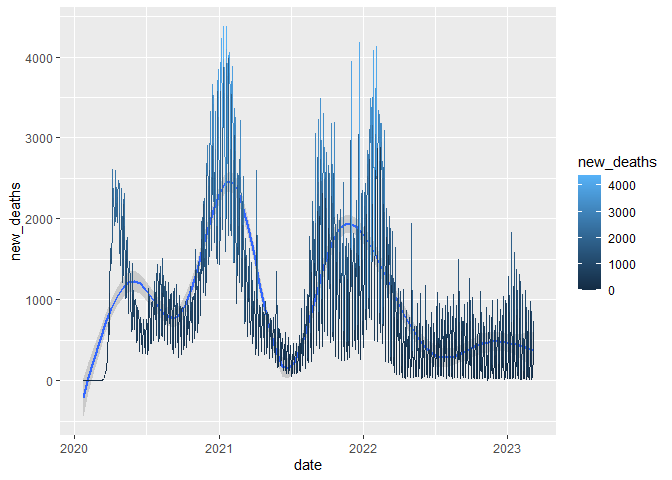

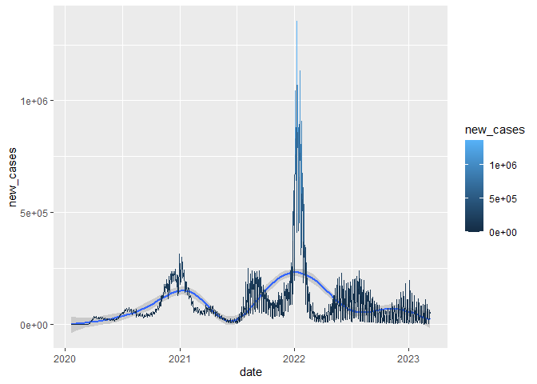

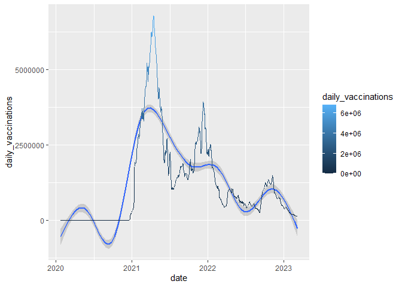

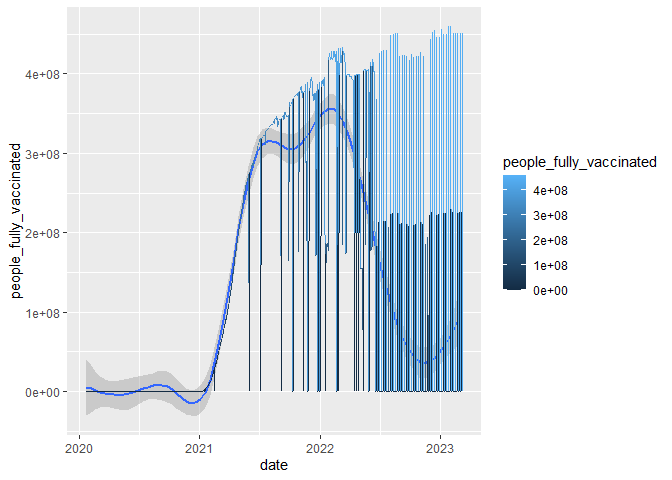

```r
newdeathp<-ggplot(data=us_dat_with_vacc, aes(x=date))+
  geom_smooth(aes(y=new_deaths, color= new_deaths))+
  geom_line(aes(y=new_deaths, color= new_deaths))

newcasep<-ggplot(data=us_dat_with_vacc, aes(x=date))+
  geom_smooth(aes(y=new_cases, color= new_cases))+
  geom_line(aes(y=new_cases, color= new_cases))

daily_vaccp<-ggplot(data=us_dat_with_vacc, aes(x=date))+
  geom_smooth(aes(y=daily_vaccinations, color= daily_vaccinations))+
  geom_line(aes(y=daily_vaccinations, color= daily_vaccinations))

total_vaccp<-ggplot(data=us_dat_with_vacc, aes(x=date))+
  geom_smooth(aes(y=people_fully_vaccinated, color= people_fully_vaccinated))+
  geom_line(aes(y=people_fully_vaccinated, color= people_fully_vaccinated))

newdeathp;newcasep;daily_vaccp;total_vaccp
```

Looks like there might be some kind of relationship between vaccinations and new deaths

Now 1et’s normalize the data so that the variables are in a 0-1 scale so we can see all data together in a graph

Create Normalization function:

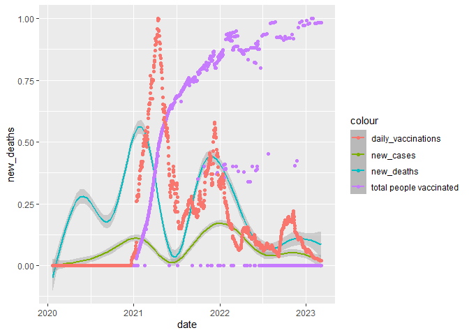

```r
norm_function<-function(dataa)
{
  normalize<-function(x){
    return((x-min(x))/(max(x)-min(x)))
  }
  datimpute<-select_if(dataa, is.numeric)
  norm<-as.data.frame(lapply(datimpute,normalize))
  norm2<-select_if(dataa,negate(is.numeric))
  all_dat<-cbind(norm2,norm)
  return(all_dat)
}

normdat<-norm_function(us_dat_with_vacc)

##visualize data
normdat%>% ggplot()+
  geom_smooth(aes(x=date,
                  y=new_deaths,
                  color="new_deaths"))+
  geom_smooth(aes(x=date,
                  y=new_cases,
                  color="new_cases"))+
  geom_point(aes(x=date,
                 y=people_vaccinated,
                 color="total people vaccinated"))+
  geom_point(aes(x=date,
                 y=daily_vaccinations,
                 color="daily_vaccinations"))
```

Looking at the overall summary of the US data, the low model fit suggests there may be other factors not included in the model that are more predictive of new deaths. Perhaps masks mandates, number of people working at home, and amount of social distancing could all have a stronger relationship with the data and predicting deaths. Those data are not in the data set.

The spike in new_deaths may be due to lifting mask restrictions in many states and people deciding to get together for social gatherings because they are tired of the pandemic. A major factor also is that new variants of COVID-19 were discovered in 2021 such as Delta and Omicron variants.

```r
modvacc<-lm(new_deaths~people_vaccinated, data=normdat)
summary(modvacc)
```

```
##
## Call:
## lm(formula = new_deaths ~ people_vaccinated, data = normdat)
##
## Residuals:
##      Min       1Q   Median       3Q      Max
## -0.26339 -0.16023 -0.06297  0.08285  0.79413
##
## Coefficients:
##                   Estimate Std. Error t value Pr(>|t|)
## (Intercept)       0.203771   0.008048  25.319   <2e-16 ***
## people_vaccinated 0.071584   0.016716   4.282    2e-05 ***
## ---
## Signif. codes:  0 '***' 0.001 '**' 0.01 '*' 0.05 '.' 0.1 ' ' 1
##
## Residual standard error: 0.2103 on 1137 degrees of freedom
## Multiple R-squared:  0.01587,    Adjusted R-squared:  0.01501
## F-statistic: 18.34 on 1 and 1137 DF,  p-value: 2.005e-05
```

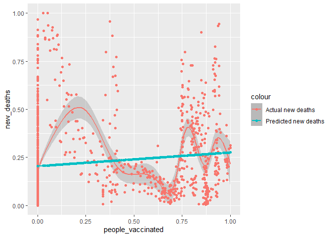

```r
modvaccpred<- normdat%>% mutate(pred=predict(modvacc))

modvaccpred %>% ggplot()+
  geom_smooth(aes(x=people_vaccinated,
                  y=new_deaths,
                  color="Actual new deaths"))+
  geom_smooth(aes(x=people_vaccinated,
                  y=pred,
                  color="Predicted new deaths"))+
  geom_point(aes(x=people_vaccinated,
                 y=new_deaths,
                 color="Actual new deaths"))+
  geom_point(aes(x=people_vaccinated,
                 y=pred,
                 color="Predicted new deaths"))
```

We can see that deaths dropped around the time vaccinations with given.

Now let’s see what happens if we focus on the part of the data where vaccinations were starting to be given.

Let’s zoom in on the data and visualize the results.

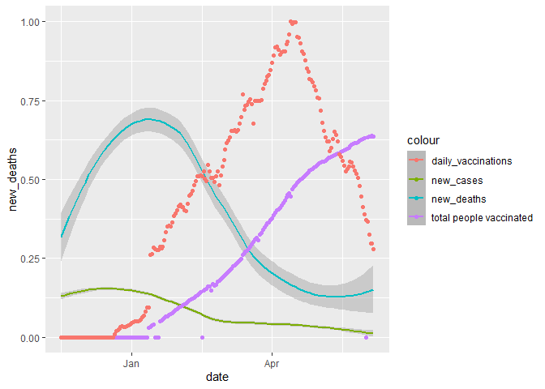

```r
normdat2<- normdat[300:500,]

normdat2%>% ggplot()+
  geom_smooth(aes(x=date,
                  y=new_deaths,
                  color="new_deaths"))+
  geom_smooth(aes(x=date,
                  y=new_cases,
                  color="new_cases"))+
  geom_point(aes(x=date,
                 y=people_vaccinated,
                 color="total people vaccinated"))+
  geom_point(aes(x=date,
                 y=daily_vaccinations,
                 color="daily_vaccinations"))
```

There is a much higher adjusted r-squared this time indicating a better fit of the data during the time in which vaccinations were given.

```r
modvacc2<-lm(new_deaths~people_vaccinated, data=normdat2)
summary(modvacc2)
```

```
##
## Call:
## lm(formula = new_deaths ~ people_vaccinated, data = normdat2)
##
## Residuals:
##      Min       1Q   Median       3Q      Max
## -0.54772 -0.12355 -0.00162  0.07371  0.45378
##
## Coefficients:
##                   Estimate Std. Error t value Pr(>|t|)
## (Intercept)        0.58932    0.01824   32.31   <2e-16 ***
## people_vaccinated -0.81513    0.05474  -14.89   <2e-16 ***
## ---
## Signif. codes:  0 '***' 0.001 '**' 0.01 '*' 0.05 '.' 0.1 ' ' 1
##
## Residual standard error: 0.1785 on 199 degrees of freedom
## Multiple R-squared:  0.527,  Adjusted R-squared:  0.5246
## F-statistic: 221.7 on 1 and 199 DF,  p-value: < 2.2e-16
```

```r
modvaccpred2<- normdat2%>% mutate(pred=predict(modvacc2))
```

We can see that new deaths dropped as more and more people received vaccinations.

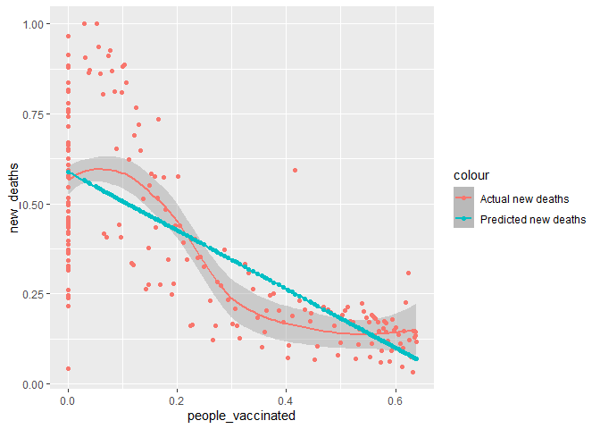

```r
modvaccpred2 %>% ggplot()+
  geom_smooth(aes(x=people_vaccinated,
                  y=new_deaths,
                  color="Actual new deaths"))+
  geom_smooth(aes(x=people_vaccinated,
                  y=pred,
                  color="Predicted new deaths"))+
  geom_point(aes(x=people_vaccinated,
                 y=new_deaths,
                 color="Actual new deaths"))+
  geom_point(aes(x=people_vaccinated,
                 y=pred,
                 color="Predicted new deaths"))
```

## Conclusions and Bias Statements

In our analysis of the vaccination data we see there isn’t much of correlation overall with total vaccinated people and prediction of new deaths. However when we focus on only the important time points when vaccinations were administered, we can see decreasing new deaths, indicating that vaccines were effective at preventing new deaths from COVID.

**Possible biases include:**

1. Recording and reporting of cases may differ for each state. We can see some number go lower then back to higher vaklues as evidence for this.
2. Lag in new cases, new deaths due to vaccine.
3. Other factors were not included in the analysis because they were not in the data sets. These include. but are not limited to: mask mandate lengths and easing of restrictions, stay at home orders and social distance. These may also be difficult to quantify.